# Fitting admixture graphs

**Purpose.** A tree assumes every population split and never mixed again. An **admixture graph** relaxes that: it allows edges where a population is a mixture of two ancestries. This exercise fits such graphs and, more importantly, asks how you would know whether a fitted graph is right — because a graph that fits is not the same as a graph that is true.

**What you will do**

- read statistics for a panel of world populations and view them as a distance matrix
- build a neighbour-joining tree and see where a tree is not enough
- fit a specified admixture graph with `qpgraph` and read the fitted values
- compare competing graphs for the same populations and decide between them
- use `treemix` to *estimate* a graph rather than specify one, adding migration edges one at a time and reading the residuals

**The data.** Precomputed statistics for **33 world populations**, a global human panel including Mbuti, Ju_hoan_North, Biaka, Yoruba, Esan, Mandenka, Masai and Datog from Africa; Sardinian, Basque, Georgian and Mozabite from west Eurasia; Han, Korean, Ami, Atayal, She and Naxi from east Asia; Papuan; Chukchi, Itelmen, Koryak, Nganasan, Tubalar and Ulchi from Siberia; Karitiana, Surui and Pima from the Americas; and `AA`, an ancient sample whose ancestry you will be asked to model.

The values are **precomputed** rather than calculated from genotypes here, which is why the exercise runs quickly. Blocked jackknife estimates of the standard errors are included, and those are what make it possible to say whether a graph fits.

**Before this** do f-statistics, which defines , and and is what admixture graphs are built from.

## Setup

All the paths used by this exercise are set in the cell below.

```
#############################################################
# ALL PATHS ARE SET HERE
# If the data or the software moves, this is the ONLY cell you
# need to change. No cell below this one uses a full path.
#############################################################

# where the shared data and the helper scripts live
DATA=/course/data/current_data/admixture_graphs
SOFTWARE=$DATA/software

# where you will do the exercise
WORK_DIR=$HOME/admixture_graphs

mkdir -p $WORK_DIR
cd $WORK_DIR

# make the paths available to the R cells below
echo $WORK_DIR > $HOME/.admixture_graphs_workdir
echo $DATA     > $HOME/.admixture_graphs_data
echo $SOFTWARE > $HOME/.admixture_graphs_software

echo --- data ---
ls $DATA
echo; echo --- populations in the worldfoci2 panel ---
ls $DATA/fdata/worldfoci2 | grep -v '\.rds$' | tr '\n' ' '
```

```
# the paths were set in the first cell of the notebook
dd <- readLines(path.expand("~/.admixture_graphs_data"))[1]       # data
wd <- readLines(path.expand("~/.admixture_graphs_software"))[1]   # helper scripts
work_d <- readLines(path.expand("~/.admixture_graphs_workdir"))[1]
setwd(work_d)

options(repr.plot.width=22, repr.plot.height=22)
suppressPackageStartupMessages({
    library(admixtools)
    library(ape)
    library(tidyverse)
    library(gplots)
    library(glue)
    source(glue("{wd}/scripts/analysis.R"))
    source(glue("{wd}/scripts/treemix_plotting2.R"))
})
getwd()
```

'/davidData/data/course/.nbrender_home/admixture_graphs'

## 1. Estimating trees

Many methods to visualize population structure between many populations can be written as functions of a *distance matrix*, like a matrix of or -values. These methods include principal component analysis, trees and admixture graphs, the latter two we will focus on today. In distance matrices, large values mean that samples are less similar to each other, in contrast to similarity matrices where large values imply samples are *more* alike.

```
#here we read all possible f2 values
f2s = read_f2(glue('{dd}/fdata/worldfoci2'))

#we arrange them into a matrix
f2_mat = f2_matrix(f2s)
```

```
heatmap.2(f2_mat, symm=T, scale="none", trace='n')
```

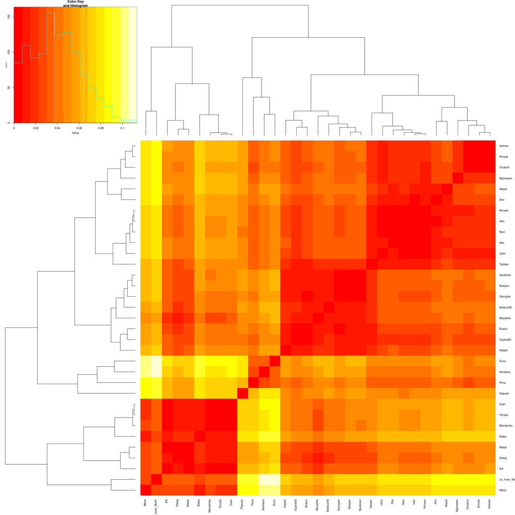

**Questions**

- The heatmap is symmetric with a zero diagonal. Why must between a population and itself be zero?
- Which pair of populations is the most distant, and does that match what you expect?

**Task 1:** Use the distance matrix in the `f2_mat`-matrix to generate a tree using the neighbor joining algorithm. Use the following functions from the `ape` package:

- `nj()` to calculate the tree
- `root()` to set an appropriate root
- `plot.phylo()` to visualize your data

In case you are not sure how these functions work, the help (typing e.g. `?nj` may help)

**Questions:**

- Can you tell which populations might be admixed?
- how does that relate to -statistics?

```
#Type your solution here
```

**Questions**

- Neighbour joining gives a tree, so it *cannot* represent admixture. What would an admixed population look like on such a tree?
- Where did you root the tree, and why does the choice matter?

## 2. Fitting admixture graphs using qpgraph

Our next task will be to use `qpgraph` to fit a graph. In contrast to `nj`, `qpgraph` does not estimate a graph, so one has to be specified. It will then fit all admixture proportions and branch lengths. One can think of this as obtaining "plausible" graphs that fit the data, without any statements whether they are the best or unique graph for that purpose. Thus, we have to specify a graph. The easiest way is to give it a list using 2 columns, where each row is anedge in the graph.

```
starting_graph = rbind(
              c("ROOT", "Mbuti"),
              c("ROOT", "AFR"),
              c("AFR", "AFR1"),
              c("AFR1", "AA"),
              c("AFR", "OOA"),
              c("OOA", "EUR"),
              c("OOA", "EAS"),
              c("EUR", "Sardinian"),
              c("EUR","AA"),
              c("EAS", "Han")
              )
```

**Questions**

- Read the edge list: which populations are at the tips, and which names are internal nodes you invented?
- Where in this graph is the admixture edge, and which population is modelled as mixed?

For this purpose, we have to define a bunch of internal nodes (a useful convention is to use ALL-CAPS for internal nodes). I.e. in our starting graph, we start at the root, where we us the *Mbuti* as an outgroup. Within Africa, we have two populations; the African component of the African-American population (*AA*), and the out-of-Africa population (OOA). Outside Africa, we split into Europe (EUR) and East Asians (EAS), represented by the *Sardinian* and *Han*, respectively. Our hypothesis is that the African-Americans have some European ancestry, therefore we add a second edge from `EUR` to `AA` to reflect that.

```
#fitting the graph is done using the qpgraph function:
G = qpgraph(f2s,starting_graph, return_fstats = T);
plot_graph(G$edges, textsize=10)
```

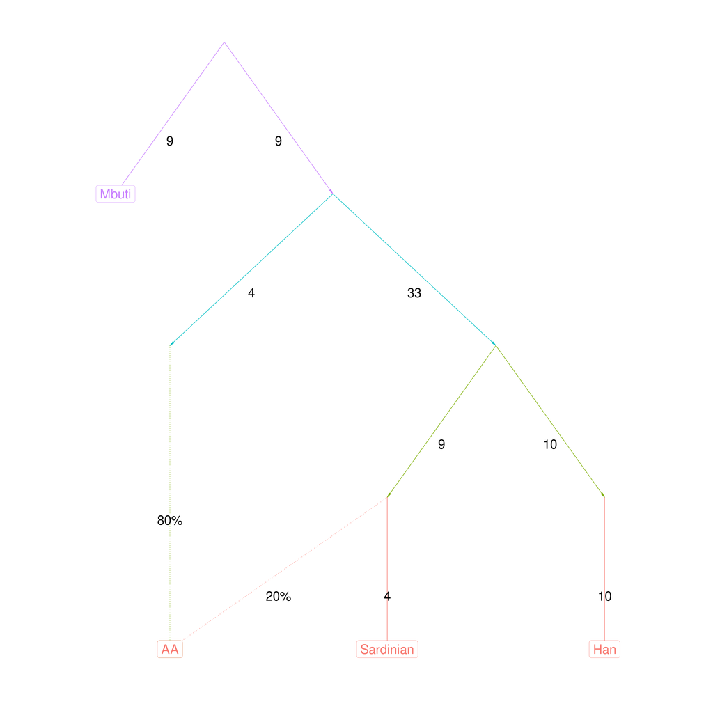

**Question**

- `qpgraph` fits branch lengths and admixture proportions but not the topology. What does it do if the topology is wrong?

Next, we can look at the fitted -statistics

```
G$f2
```

A tibble: 6 × 8

| pop1 <chr> | pop2 <chr> | est <dbl> | se <dbl> | fit <dbl> | diff <dbl> | z <dbl> | p <dbl> |
| --- | --- | --- | --- | --- | --- | --- | --- |
| Mbuti | AA | 0.02298698 | 0.0002453600 | 0.02298578 | 1.193698e-06 | 0.004865088 | 0.9961182 |
| Mbuti | Sardinian | 0.06382167 | 0.0004345402 | 0.06381450 | 7.172719e-06 | 0.016506458 | 0.9868303 |
| Mbuti | Han | 0.07039192 | 0.0004803555 | 0.07038467 | 7.253171e-06 | 0.015099589 | 0.9879527 |
| AA | Sardinian | 0.03346784 | 0.0003150060 | 0.03346382 | 4.022782e-06 | 0.012770494 | 0.9898109 |
| AA | Han | 0.04344543 | 0.0003414332 | 0.04344026 | 5.170399e-06 | 0.015143225 | 0.9879179 |
| Sardinian | Han | 0.03200879 | 0.0003060188 | 0.03200954 | -7.502779e-07 | -0.002451738 | 0.9980438 |

**Questions**

- Compare `est` with `fit` for each . Which statistics does the graph reproduce well and which does it miss?
- The `z` column is the deviation in standard errors. Above what value would you start to disbelieve the graph?

the columns

If there are no Z-scores above 3 (or below -3), the model is often considered a fit to the data (again, with no claim about whether it is the best model). In this simple example, we only have 6 -values and estimate 6 parameters (5 branch lengths and one admixture coefficient), so it is not surprising that we obtain a perfect fit.

**Task 2:** Assume we want to compare this model where the `AA`-population only has African Ancestry. For this purpose, remove the edge from `EUR` to `AA` from the graph. Does this model also fit?

```
# Type your solution here
```

**Question**

- You have now fitted two graphs to the same data. A better-fitting graph has more parameters — how would you decide whether the improvement is worth it?

**Task 3:** We picked `Sardinian` as a "proxy" for Europeans, and `Mbuti` as a proxy for Africans. What happens if we substitute them for other populations from the same region (e.g. `Sardinian -> Basque`, `Mbuti -> Yoruba`). What happens if we all add `Yoruba`, `Mbuti`, `Sardinian` and `Basque` to the model?

```
# Type your solution here
```

**Questions**

- Sardinian stands in for "European" and Mbuti for "African". What does using one population as a proxy for a whole continent assume?
- If you swapped Sardinian for Basque, would you expect the fit to change?

## 3. Estimating Admixture Graphs using Treemix

`qpgraph` has the drawback that the user needs to specify the graph. This has the advantage that we retain fine-scale control over the fitting, but in many cases we would like to have a way to estimate the tree from data.

This is the problem addressed by `treemix` [(Pickrell & Pritchard 2012)](https://journals.plos.org/plosgenetics/article?id=10.1371/journal.pgen.1002967). Unfortunately, the program has not been maintained for the last five+ years, so it is a little bit tedious to use. For this exercise, I converted the input files for the `world`-data set to treemix format (in `treemix/worldfoci2.treemix.in.gz`), and ran treemix with 0 to 5 admixture edges ((`-m 0` to `-m 5`), the resulting output are stored in the `treemix`-folder as well

```
#system("treemix -i treemix/worldfoci2.treemix.in.gz -m 0 -k 1000 -root Mbuti -o treemix/worldfoci2.treemix.m0")
#system("treemix -i treemix/worldfoci2.treemix.in.gz -m 1 -k 1000 -root Mbuti -o treemix/worldfoci2.treemix.m1")
#system("treemix -i treemix/worldfoci2.treemix.in.gz -m 2 -k 1000 -root Mbuti -o treemix/worldfoci2.treemix.m2")
#system("treemix -i treemix/worldfoci2.treemix.in.gz -m 3 -k 1000 -root Mbuti -o treemix/worldfoci2.treemix.m3")
#system("treemix -i treemix/worldfoci2.treemix.in.gz -m 4 -k 1000 -root Mbuti -o treemix/worldfoci2.treemix.m4")
#system("treemix -i treemix/worldfoci2.treemix.in.gz -m 5 -k 1000 -root Mbuti -o treemix/worldfoci2.treemix.m5")
```

**Question**

- These treemix commands are commented out because they take too long to run here. What does `-m` control, and what does `-root Mbuti` do?

The output of `treemix` will be wo plots; one is the fitted graph, and one is a plot of the residuals that gives us some information about which pairs of populations are not fit well. We can use the `plot_treemix` and `plot_resid`-functions for this purpose: (these will produce some warnings, which we can ignore)

```
tm = plot_treemix(glue('{dd}/treemix/worldfoci2.treemix.m0'))
```

[output not shown]

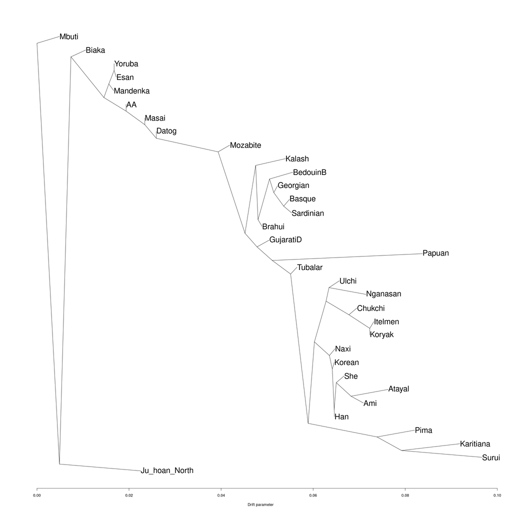

**Questions**

- With `m=0` treemix fits a pure tree. Which populations does it place next to each other?
- Compare this with your neighbour-joining tree. Do they agree?

```
tree = nj(f2_mat)
res = plot_resid(glue('{dd}/treemix/worldfoci2.treemix.m0'), pop_order=get_tip_order(tree))
```

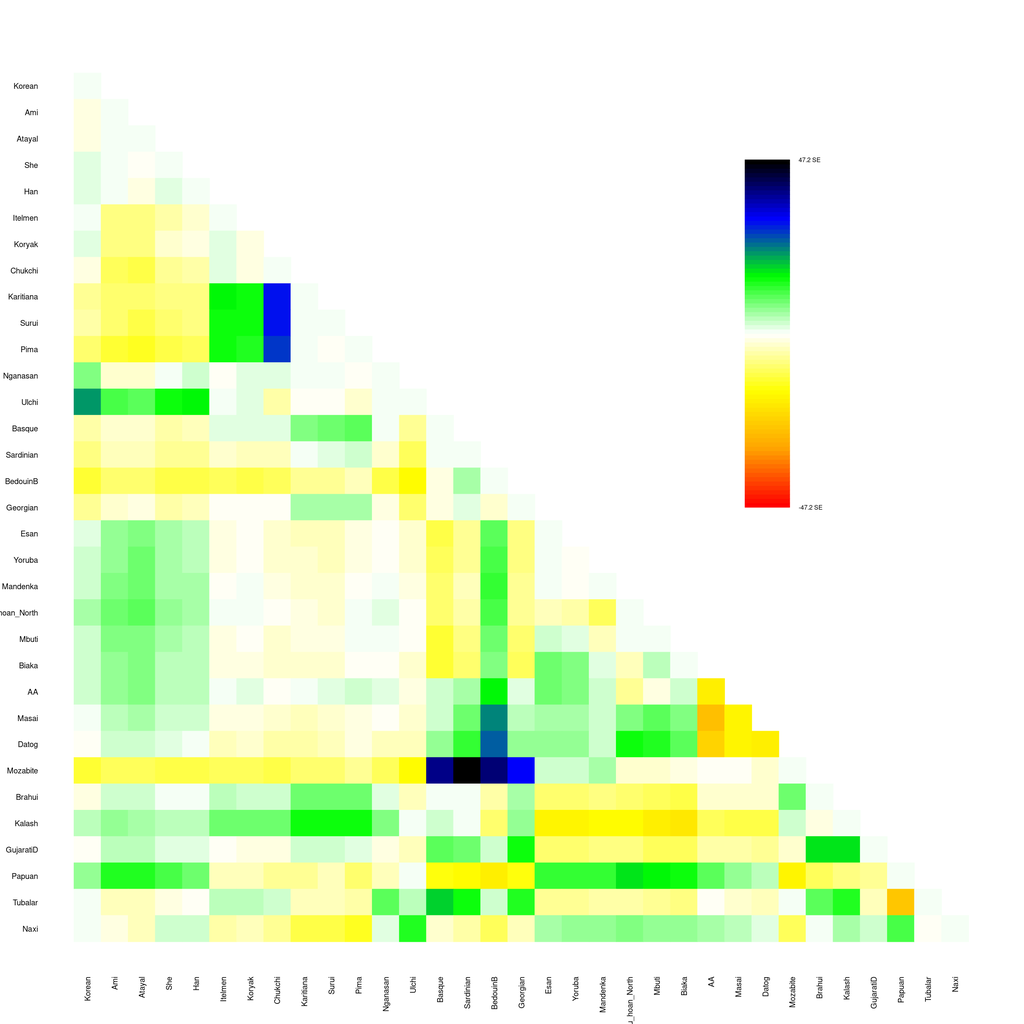

**Questions**

- The residual plot shows what the model fails to explain. Which pairs have the largest residuals?
- A large positive residual means two populations are more closely related than the tree allows. What would explain that?

```
#Type your commands here
```

**Task 4**: Have a look at the admixture graphs and residual plots for `m=0` to `m=5`.

- Does the fit improve when adding more admixture events?
- Can you predict how the fit improves?
- Does `m=5` provide a good fit?

**Questions**

- As you add migration edges from `m=0` to `m=5`, do the residuals keep improving?
- At some point extra edges stop being informative. How would you choose where to stop?
- treemix estimates a graph while qpgraph fits one you specify. Which would you trust more, and when?

```
# Add your code here
```

# Solutions

### Task 1

```
f2_mat %>% nj %>% root('Mbuti') %>% plot
```

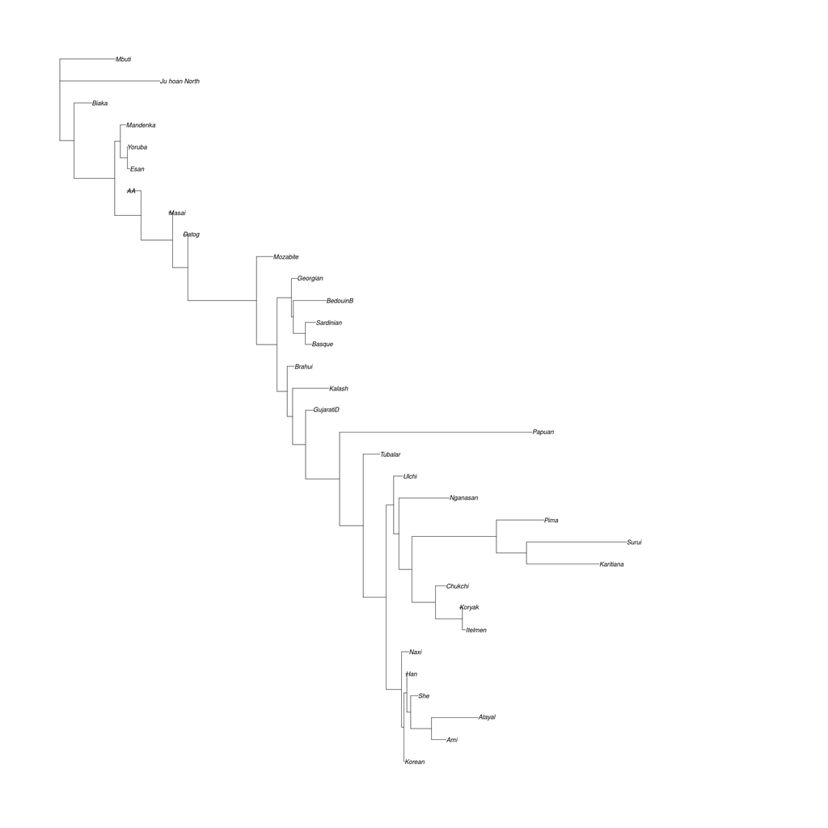

### Task 2

```
graph_task2 = rbind(
              c("ROOT", "Mbuti"),
              c("ROOT", "AFR"),
              c("AFR", "AFR1"),
              c("AFR1", "AA"),
              c("AFR", "OOA"),
              c("OOA", "EUR"),
              c("OOA", "EAS"),
              c("EUR", "Sardinian"),
              #c("EUR","AA"),
              c("EAS", "Han")
              )
G2 = qpgraph(f2s,graph_task2,return_fstats=T);
plot_graph(G2$edges, textsize=10)
```

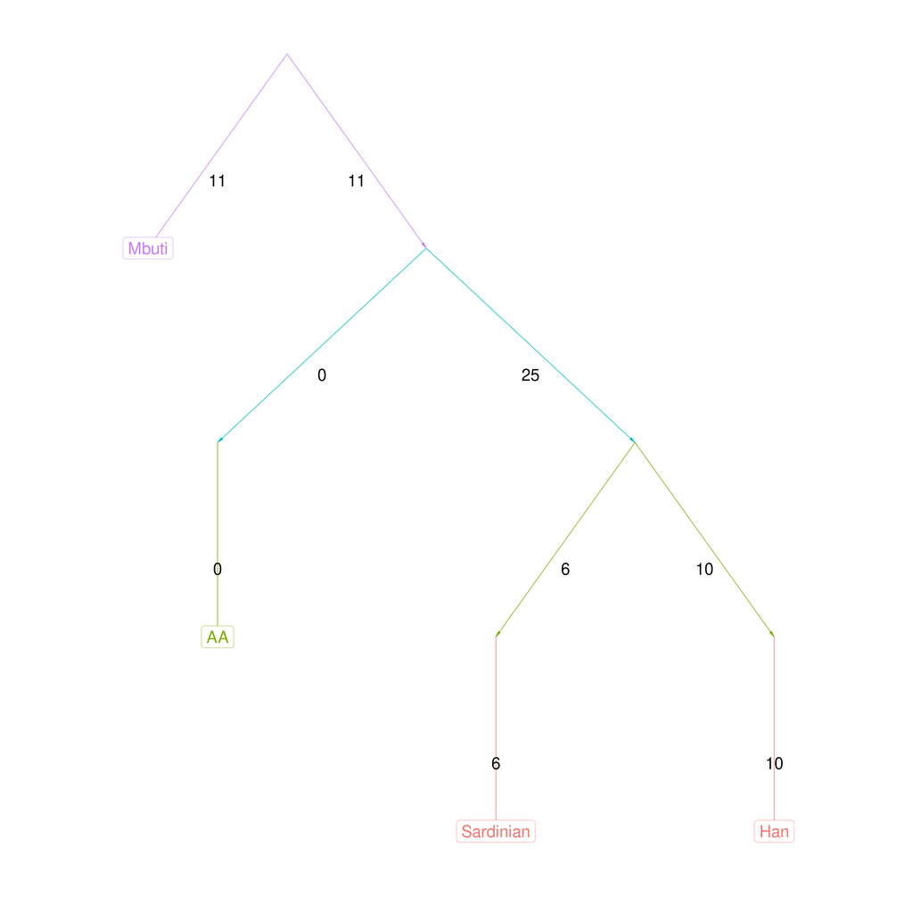

### Task 3

```
graph_task3 = rbind(
              c("ROOT", "Mbuti"),
              c("ROOT", "AFR"),
              c("AFR", "AFR1"),
              c("AFR1", "AA"),
              c("AFR", "OOA"),
              c("OOA", "EUR"),
              c("OOA", "EAS"),
              c("EUR", "Basque"),
              #c("EUR","AA"),
              c("EAS", "Han")
              )
G3 = qpgraph(f2s,graph_task3,return_fstats=T);
plot_graph(G3$edges, textsize=10)
```

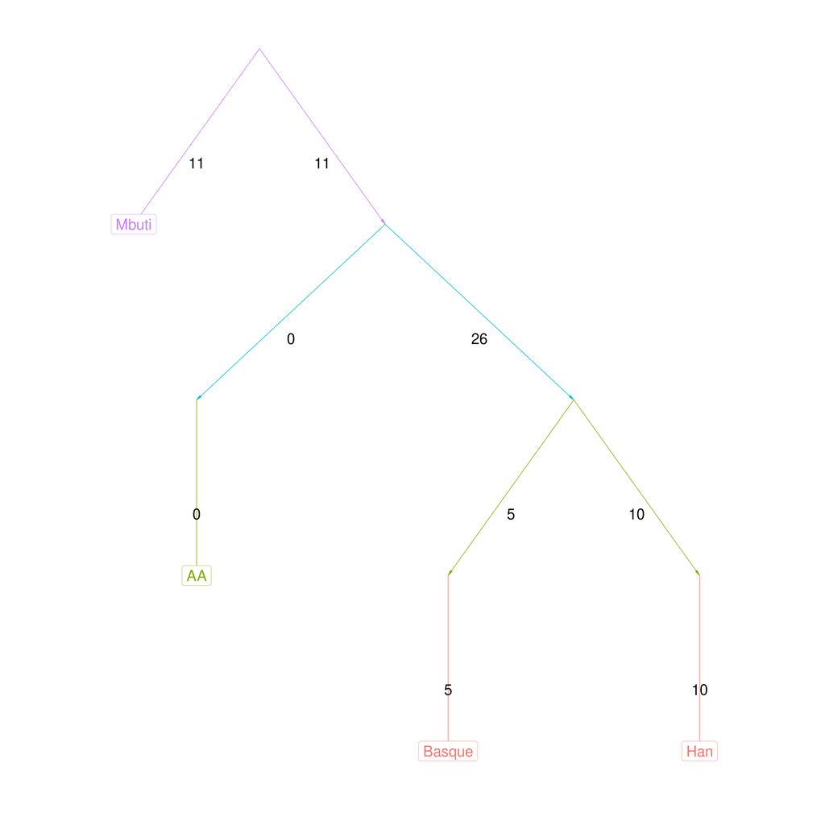

### Task 4

```
for(i in 0:5){
    plot_treemix(glue('{dd}/treemix/worldfoci2.treemix.m{i}'))
    plot_resid(glue('{dd}/treemix/worldfoci2.treemix.m{i}'), pop_order=get_tip_order(tree))
    }
```

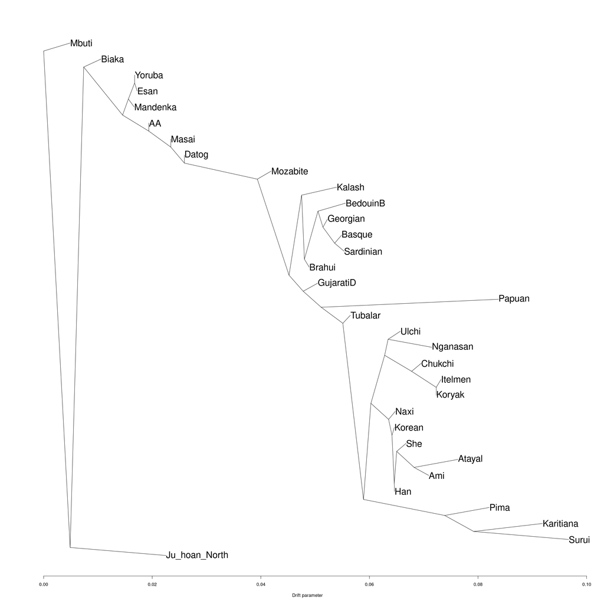

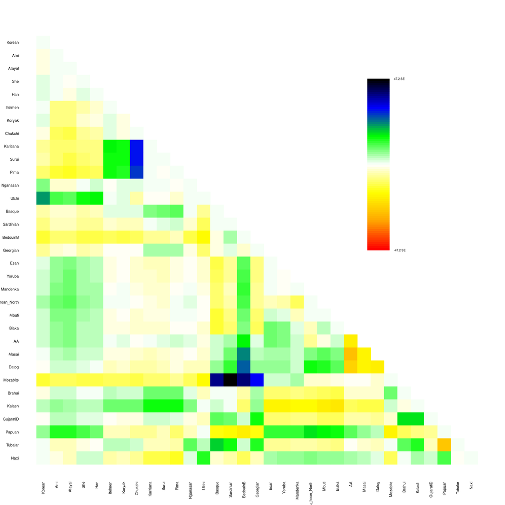

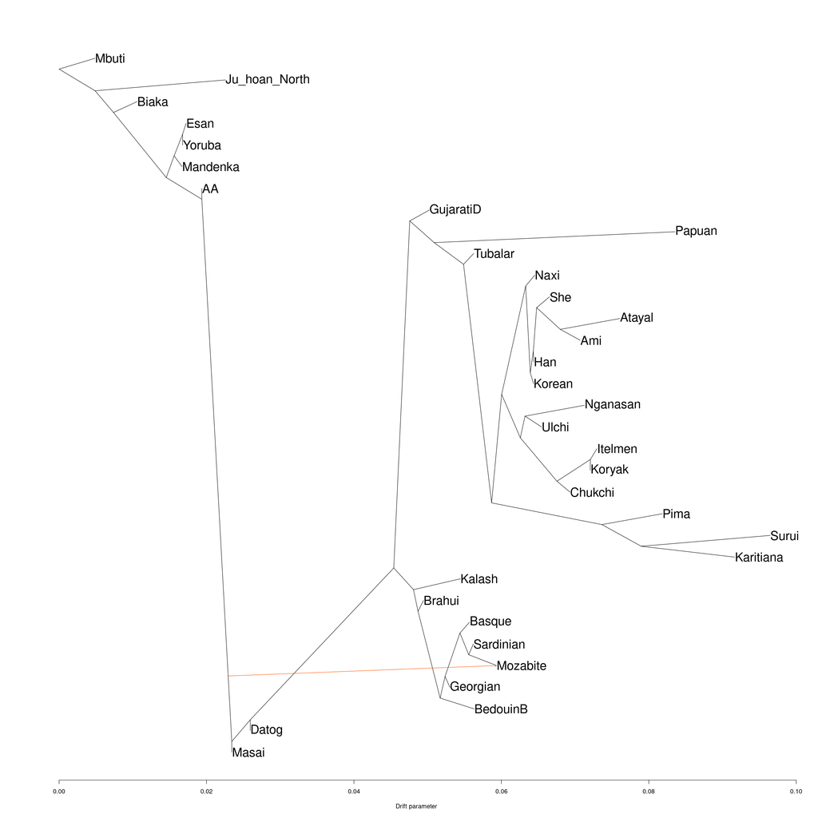

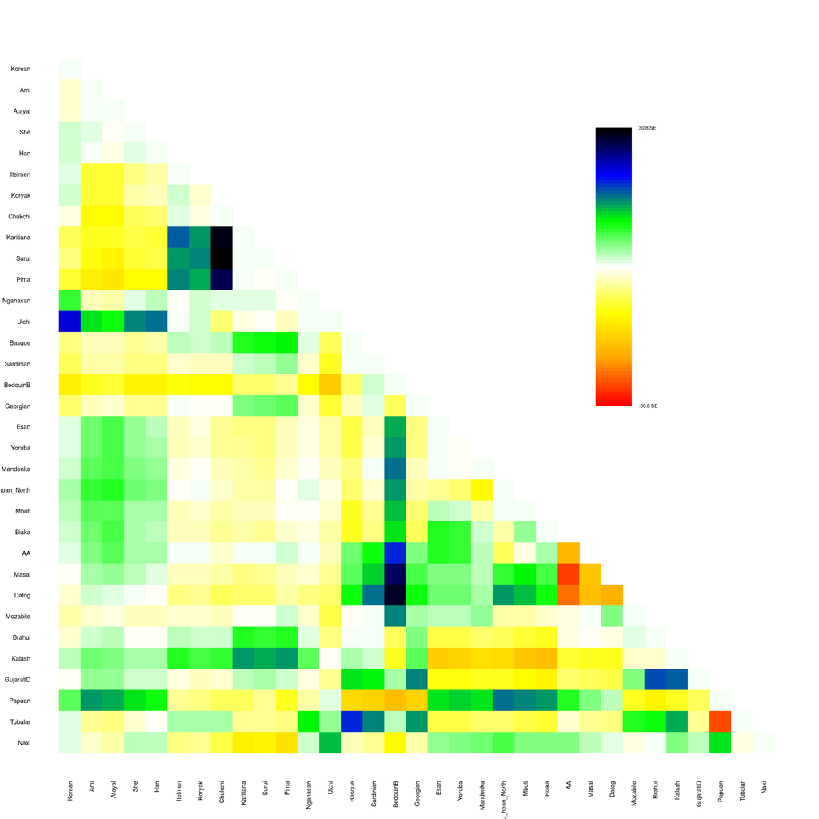

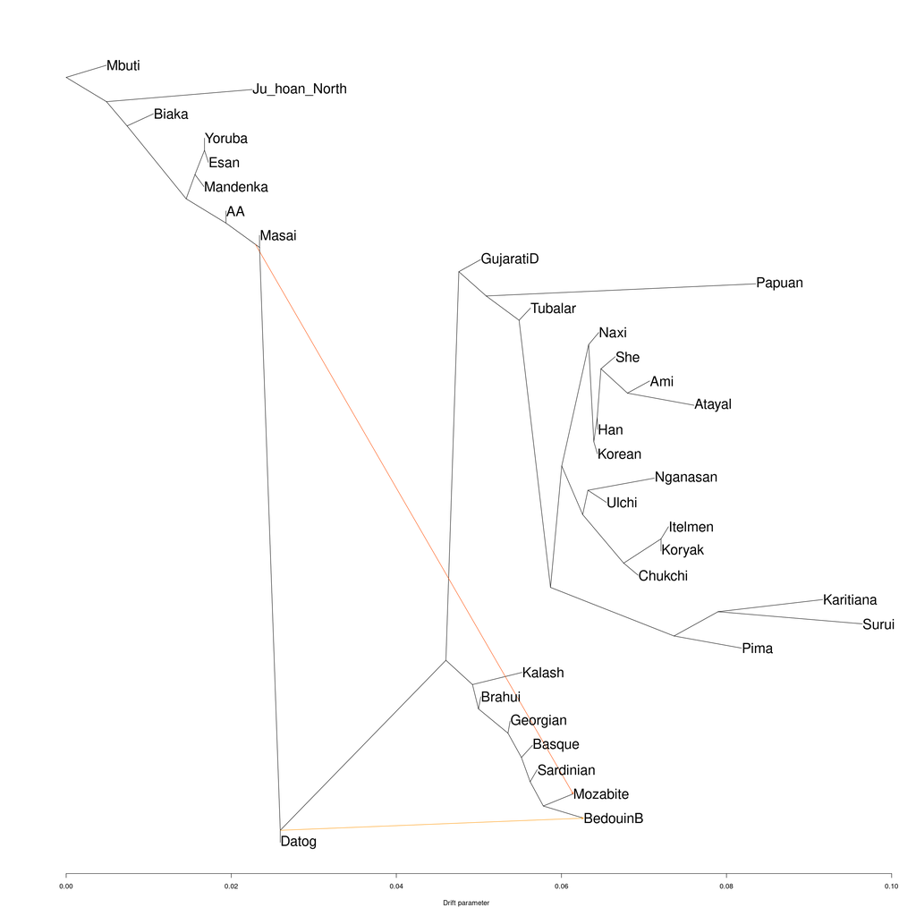

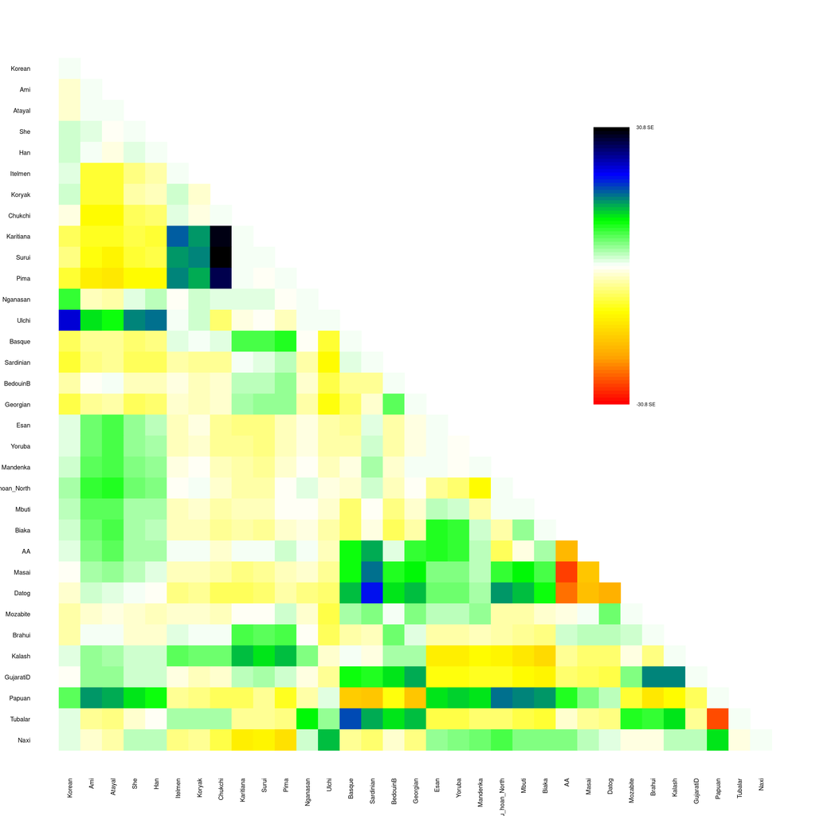

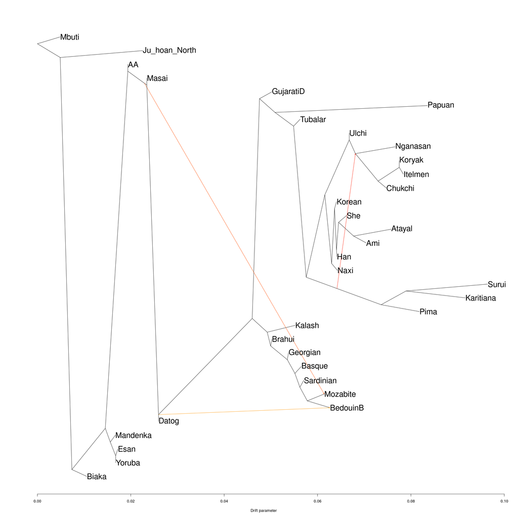

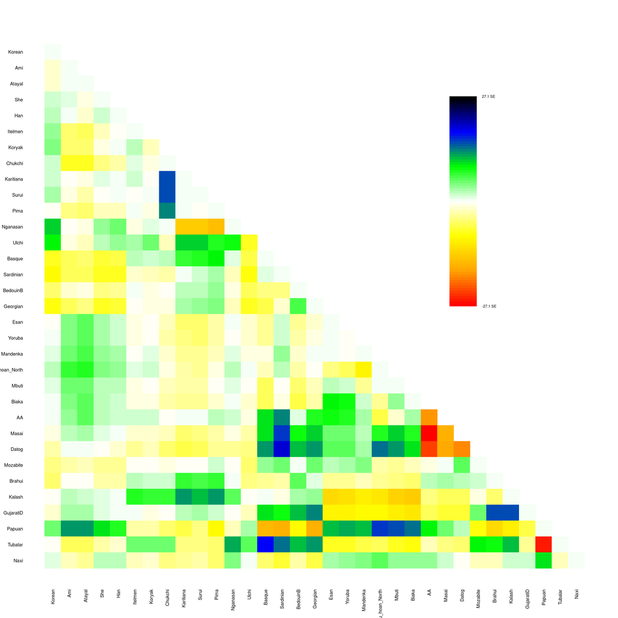

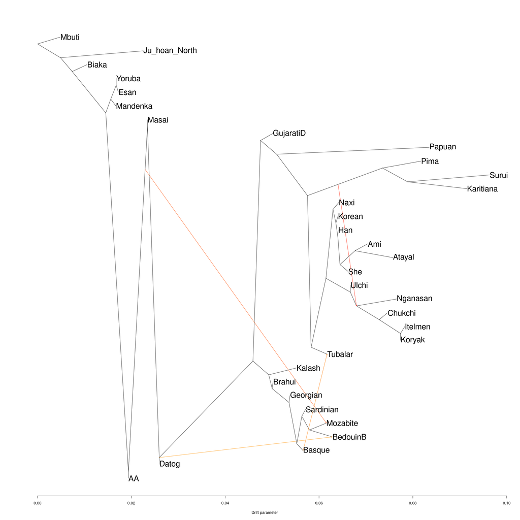

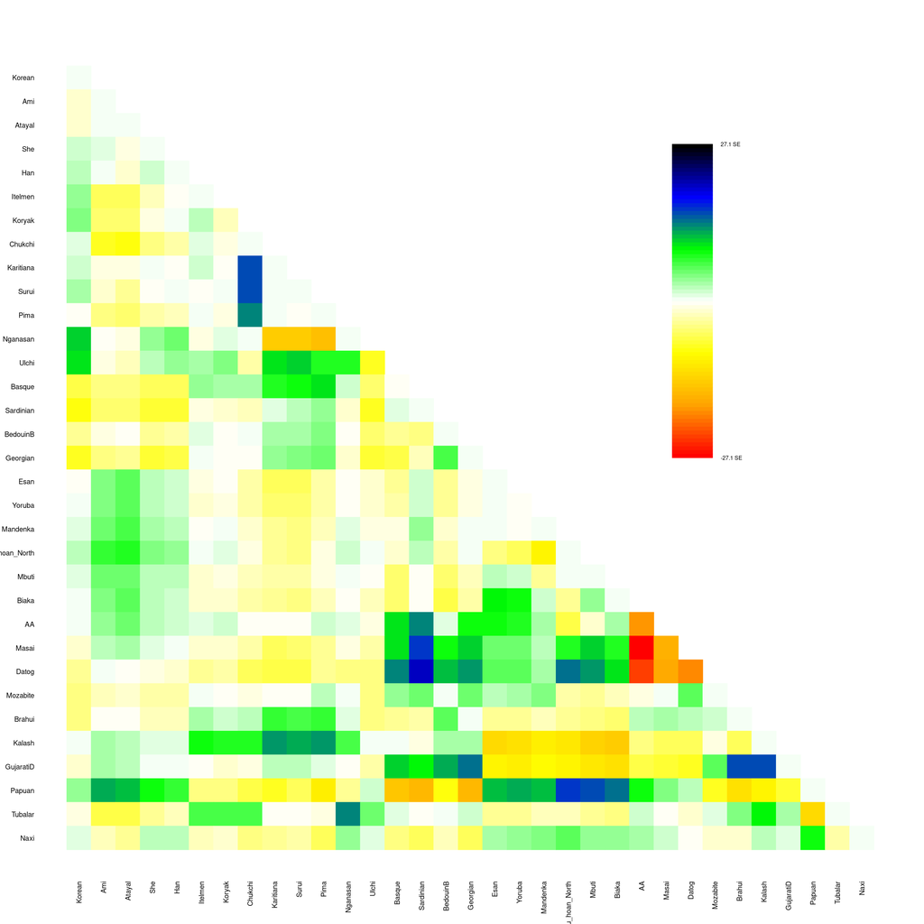

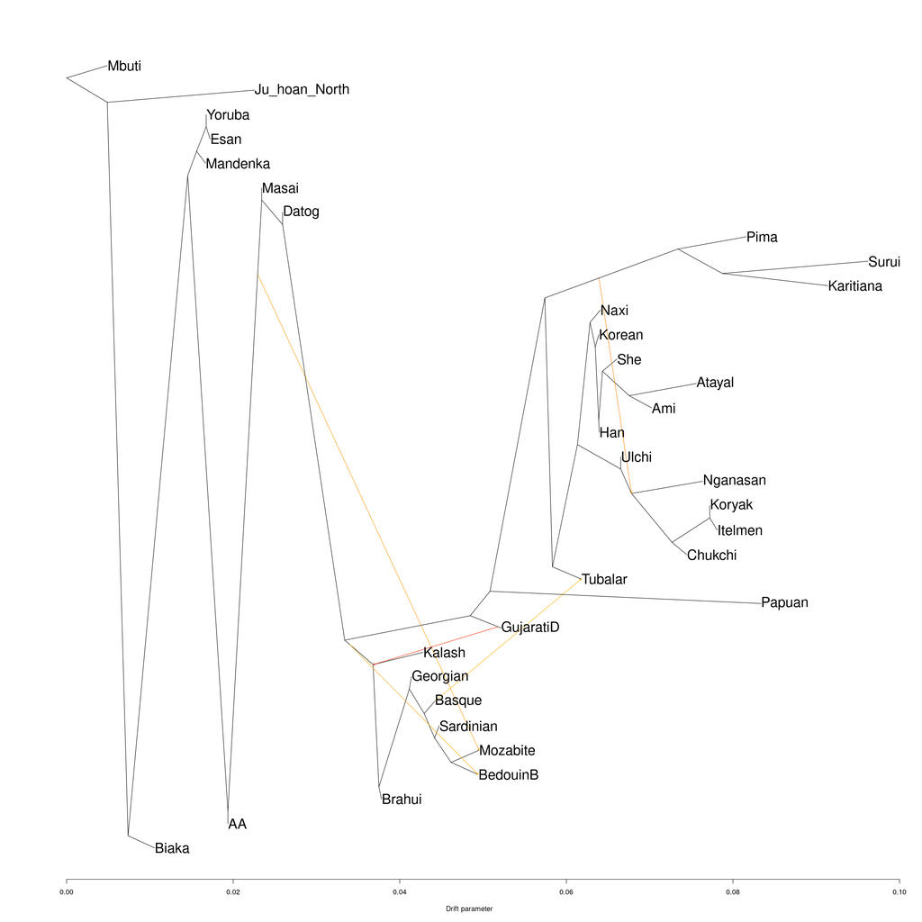

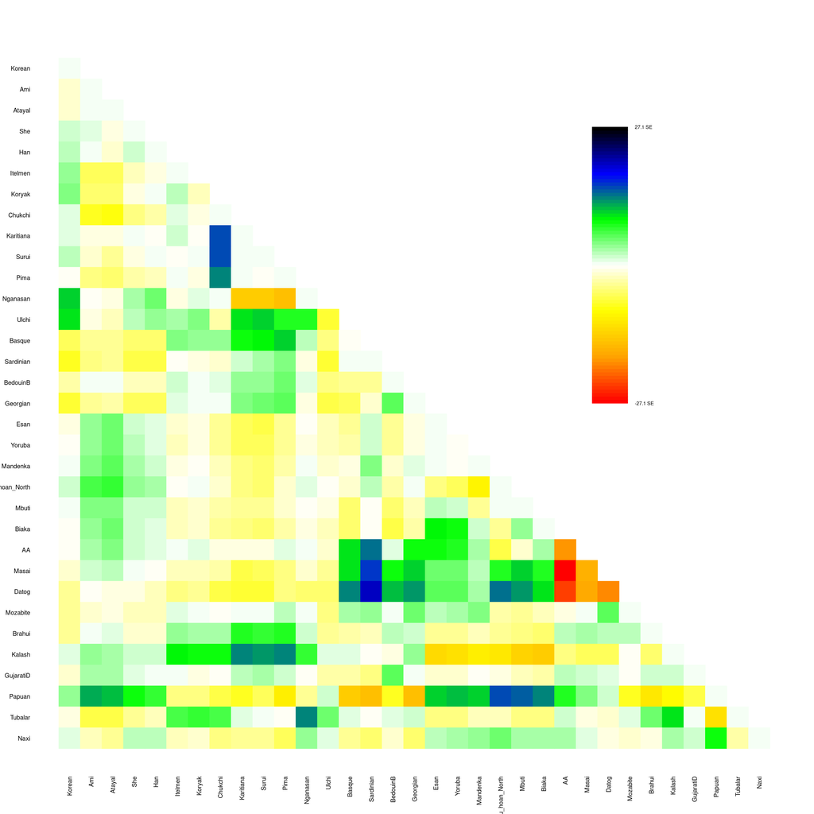

**Question**

- Looking across m=0 to m=5 together: which migration edges appear consistently, and which come and go?

### Run the cell below to take the quiz

```
from jupyterquiz import display_quiz

display_quiz("https://raw.githubusercontent.com/popgenDK/courses/main/current_exercises/admixture/quiz/admixture_graphs.json")
```